# Spotify Data Analysis

Trixie

16 5 2021

# Installing packages

```r
library(tidyverse)
library(dplyr)
library(ggplot2)
```

## Reading the data and take a quick look

```r
Spotify <- read_csv("top10s.csv")
```

## I opt to rename the column X1 with numbers

```r
Spotify <-Spotify%>%rename(Number = X1)
summary(Spotify)
```

```
##      Number         title              artist           top genre
##  Min.   :  1.0   Length:603         Length:603         Length:603
##  1st Qu.:151.5   Class :character   Class :character   Class :character
##  Median :302.0   Mode  :character   Mode  :character   Mode  :character
##  Mean   :302.0
##  3rd Qu.:452.5
##  Max.   :603.0
##       year           bpm             nrgy           dnce
##  Min.   :2010   Min.   :  0.0   Min.   : 0.0   Min.   : 0.00
##  1st Qu.:2013   1st Qu.:100.0   1st Qu.:61.0   1st Qu.:57.00
##  Median :2015   Median :120.0   Median :74.0   Median :66.00
##  Mean   :2015   Mean   :118.5   Mean   :70.5   Mean   :64.38
##  3rd Qu.:2017   3rd Qu.:129.0   3rd Qu.:82.0   3rd Qu.:73.00
##  Max.   :2019   Max.   :206.0   Max.   :98.0   Max.   :97.00
##        dB               live            val             dur
##  Min.   :-60.000   Min.   : 0.00   Min.   : 0.00   Min.   :134.0
##  1st Qu.: -6.000   1st Qu.: 9.00   1st Qu.:35.00   1st Qu.:202.0
##  Median : -5.000   Median :12.00   Median :52.00   Median :221.0
##  Mean   : -5.579   Mean   :17.77   Mean   :52.23   Mean   :224.7
##  3rd Qu.: -4.000   3rd Qu.:24.00   3rd Qu.:69.00   3rd Qu.:239.5
##  Max.   : -2.000   Max.   :74.00   Max.   :98.00   Max.   :424.0
##      acous            spch             pop
##  Min.   : 0.00   Min.   : 0.000   Min.   : 0.00
##  1st Qu.: 2.00   1st Qu.: 4.000   1st Qu.:60.00
##  Median : 6.00   Median : 5.000   Median :69.00
##  Mean   :14.33   Mean   : 8.358   Mean   :66.52
##  3rd Qu.:17.00   3rd Qu.: 9.000   3rd Qu.:76.00
##  Max.   :99.00   Max.   :48.000   Max.   :99.00
```

## let’s check the genre

I would like to see how the genre is distributed and next I will separate the first and the rest of the genre

```r
table(Spotify$`top genre`)
```

```
##
##              acoustic pop              alaska indie           alternative r&b
##                         2                         1                         1
##                   art pop               atl hip hop          australian dance
##                         8                         5                         6
##        australian hip hop            australian pop             barbadian pop
##                         1                         5                        15
##               baroque pop               belgian edm                  big room
##                         2                         2                        10
##                  boy band              british soul                   brostep
##                        15                        11                         2
## canadian contemporary r&b          canadian hip hop            canadian latin
##                         9                         2                         1
##              canadian pop                 candy pop               celtic rock
##                        34                         2                         1
##               chicago rap             colombian pop                complextro
##                         1                         3                         6
##      contemporary country                 dance pop                danish pop
##                         1                       327                         1
##           detroit hip hop                 downtempo                       edm
##                         2                         2                         5
##                   electro             electro house           electronic trap
##                         2                         1                         2
##                electropop               escape room                  folk-pop
##                        13                         2                         2
##          french indie pop                   hip hop                   hip pop
##                         1                         4                         6
##                 hollywood                     house                 indie pop
##                         1                         1                         2
##   irish singer-songwriter                     latin              metropopolis
##                         1                         4                         1
##              moroccan pop                neo mellow            permanent wave
##                         1                         9                         4
##                       pop            tropical house
##                        60                         3
```

```r
Spotify <-Spotify%>%separate((`top genre`),c("variable","genre"),extra='merge')
```

Now, lets regroup and simplify the genre

```r
other <-c("complextro","downtempo","brostep","electro","electronic","escape","folk-pop","hollywood","house","irish","permanent","neo","metropolis","tropical")
Spotify$genre[Spotify$variable %in% other]  <- 'Other'
Spotify$genre[Spotify$variable =='hip']  <- 'hip hop'
Spotify$genre[Spotify$variable =='latin']  <- 'latin'
Spotify$genre[Spotify$variable =='boy']  <- 'pop'
Spotify$genre[Spotify$variable =='french']  <- 'pop'
Spotify$genre[Spotify$variable =='electropop']  <- 'pop'
Spotify$genre[Spotify$variable =='pop']  <- 'pop'
Spotify$genre[Spotify$genre=='contemporary r&b'] <-'r&b'
Spotify$genre[Spotify$genre=='room'] <-'Other'
table(Spotify$genre)
```

```
##
## country   dance     edm hip hop   indie   latin   Other     pop     r&b     rap
##       1       6       2      20       1       5      46     493      10       1
##    rock    soul
##       1      11
```

```r
miss <- colSums(is.na(Spotify))
print(miss[miss>0])
```

```
## genre
##     6
```

```r
Spotify <-na.omit(Spotify)
```

And now I have the simple genre and I will begin my data exploration

## Data exploration

I wanna know which song is the most popular song? Which artist has the most popular song from 2010-2019? and which artist has most popular song in 2019 By running the codes I know that, the most popular song in 2019 is “Memories by Maroon 5”, Katy Perry has the most popular songs from 2010 - 2019 and Ed Sheeran has the most popular songs in 2019

```r
most_popular <- Spotify%>%arrange(desc(pop))
most_popular
```

```
## # A tibble: 597 x 16
##    Number title artist variable genre  year   bpm  nrgy  dnce    dB  live   val
##     <dbl> <chr> <chr>  <chr>    <chr> <dbl> <dbl> <dbl> <dbl> <dbl> <dbl> <dbl>
##  1    573 "Mem~ Maroo~ pop      pop    2019    91    32    76    -7     8    57
##  2    574 "Los~ Selen~ dance    pop    2019   102    34    51    -9    21     9
##  3    575 "Som~ Lewis~ pop      pop    2019   110    41    50    -6    11    45
##  4    576 "Se\~ Shawn~ canadian pop    2019   117    54    76    -6     9    75
##  5    577 "How~ Sam S~ pop      pop    2019   111    68    48    -5     8    35
##  6    578 "Sou~ Ed Sh~ pop      pop    2019    98    62    86    -6     9    67
##  7    579 "Tra~ SHAED  electro~ pop    2019   127    46    62    -6    14    50
##  8    580 "Hap~ Marsh~ brostep  Other  2019   100    79    69    -3    17    67
##  9    581 "Tru~ Lizzo  escape   Other  2019   158    62    72    -3    12    41
## 10    582 "Goo~ Lizzo  escape   Other  2019    96    89    67    -3    74    48
## # ... with 587 more rows, and 4 more variables: dur <dbl>, acous <dbl>,
## #   spch <dbl>, pop <dbl>
```

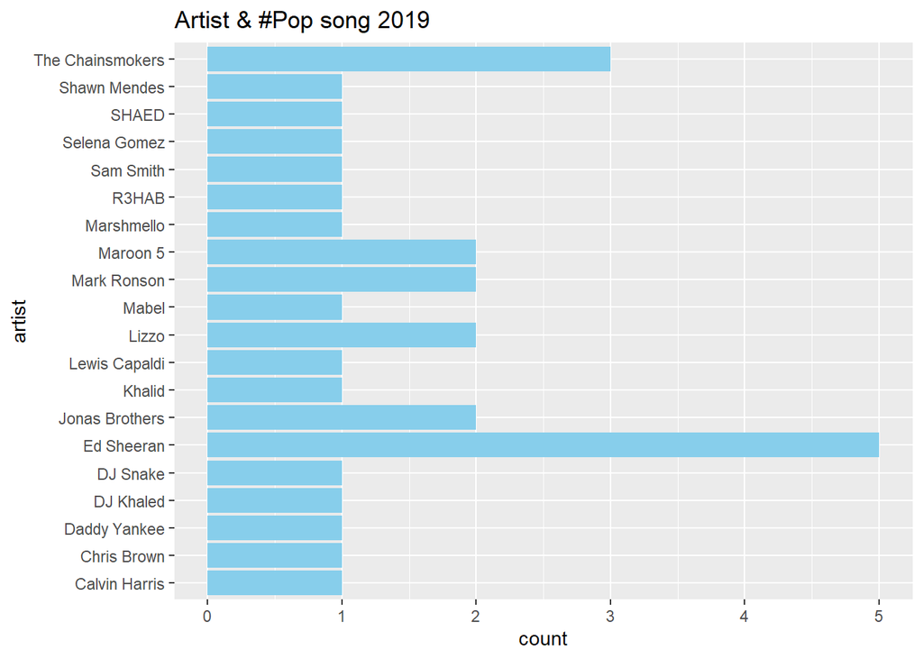

```r
plot_most_popular <-most_popular%>%filter(year==2019)%>%ggplot(aes(artist))+geom_bar(fill="skyblue")+coord_flip()+ggtitle("Artist & #Pop song 2019")
plot_most_popular
```

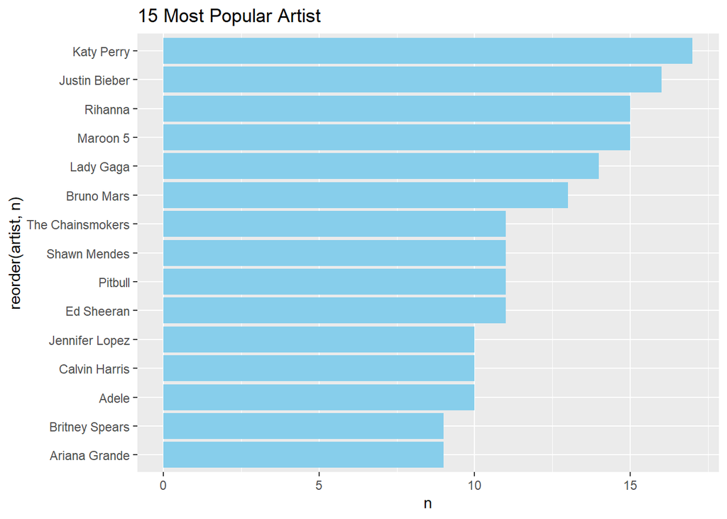

```r
most_popular_artist <- most_popular%>%count(artist)%>%arrange(desc(n))
most_popular_artist%>%head(15)%>%ggplot(aes(x=reorder(artist,n),y=n))+geom_col(fill="skyblue")+ggtitle("15 Most Popular Artist")+coord_flip()
```

## Measure Analysis

##1. Analyze the duration Most of the song has a duration of 3-4 mins There is an outlier in pop category, we have song with most/min duration The longest song (424s) is by Justin Timberlake “TKO” & the shortest song (134s) is by Justin Bieber “Mark My Words” Both records are by Justins :)

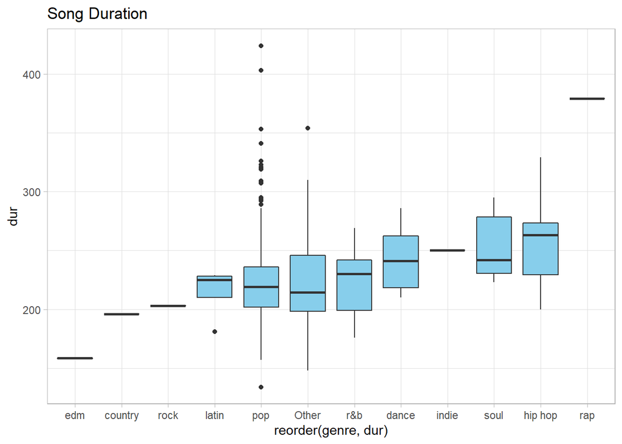

```r
duration <-Spotify%>%ggplot(aes(x=reorder(genre,dur),y=dur))+geom_boxplot(fill="skyblue")+ggtitle("Song Duration")+theme_light()
duration
```

```r
max_pop <-Spotify%>%filter(dur>=400)%>%group_by(artist)%>%summarise(title,dur)
max_pop
```

```
## # A tibble: 2 x 3
##   artist            title                                                    dur
## * <chr>             <chr>                                                  <dbl>
## 1 Florence + The M~ "Wish That You Were Here - From \x93Miss Peregrine\x9~   403
## 2 Justin Timberlake "TKO"                                                    424
```

```r
min_pop <-Spotify%>%filter(dur<=150)%>%group_by(artist)%>%summarise(title,dur)
min_pop
```

```
## # A tibble: 2 x 3
##   artist        title                             dur
## * <chr>         <chr>                           <dbl>
## 1 Justin Bieber Mark My Words                     134
## 2 R3HAB         All Around The World (La La La)   148
```

##2. Analyze the bpm Most songs have bpm around 100-150 bpm, which some few songs from pop genre has bpm >200bpm Those are : LA love by Fergie, How Ya Doin? by Little Mix and FourFiveSeconds by Rihanna

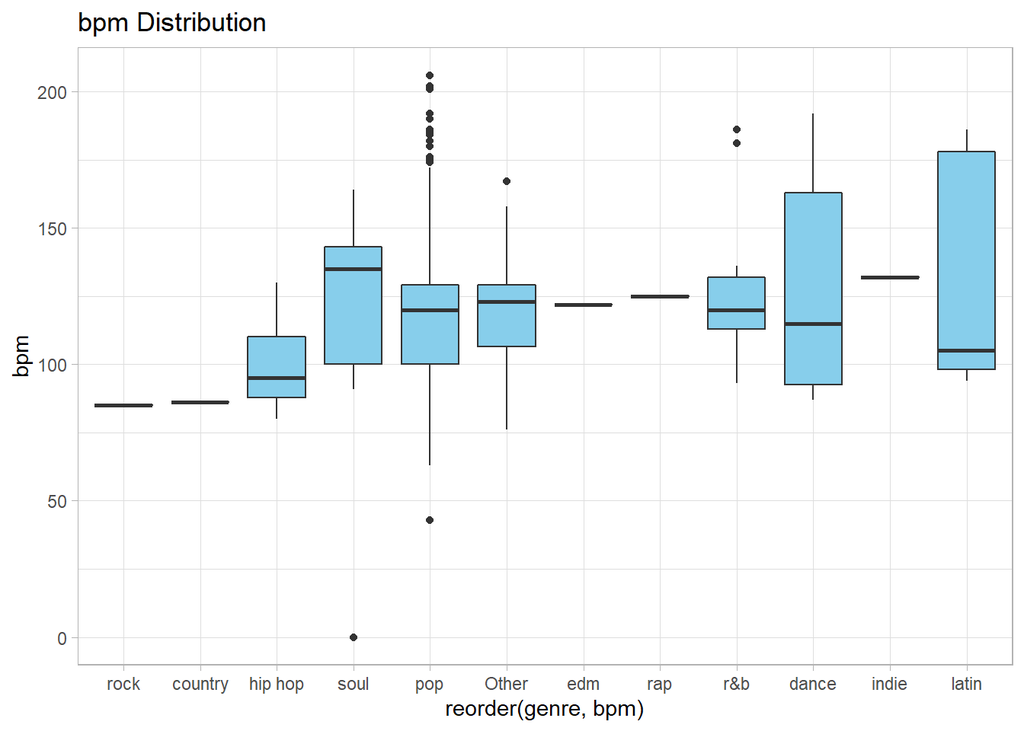

```r
bpm <- Spotify%>%ggplot(aes(x=reorder(genre,bpm),y=bpm))+geom_boxplot(fill="skyblue")+ggtitle("bpm Distribution")+theme_light()
bpm
```

```r
bpm_most <-Spotify%>%filter(bpm>=200)%>%group_by(artist)%>%summarise(title,bpm)
bpm_most
```

```
## # A tibble: 3 x 3
##   artist     title                                 bpm
## * <chr>      <chr>                               <dbl>
## 1 Fergie     L.A.LOVE (la la)                      202
## 2 Little Mix How Ya Doin'? (feat. Missy Elliott)   201
## 3 Rihanna    FourFiveSeconds                       206
```

##3. Analyze the energy Not a big suprise here, the genre pop, latin, dance & rock are the genre with median >= 75 So if we need a pick me up songs perhaps looks from one of this genre to boost our mood, next lets find from which artist? Martin Solveig Hello and Jonas Brother Pom Pom are the songs with highest energy, at 98

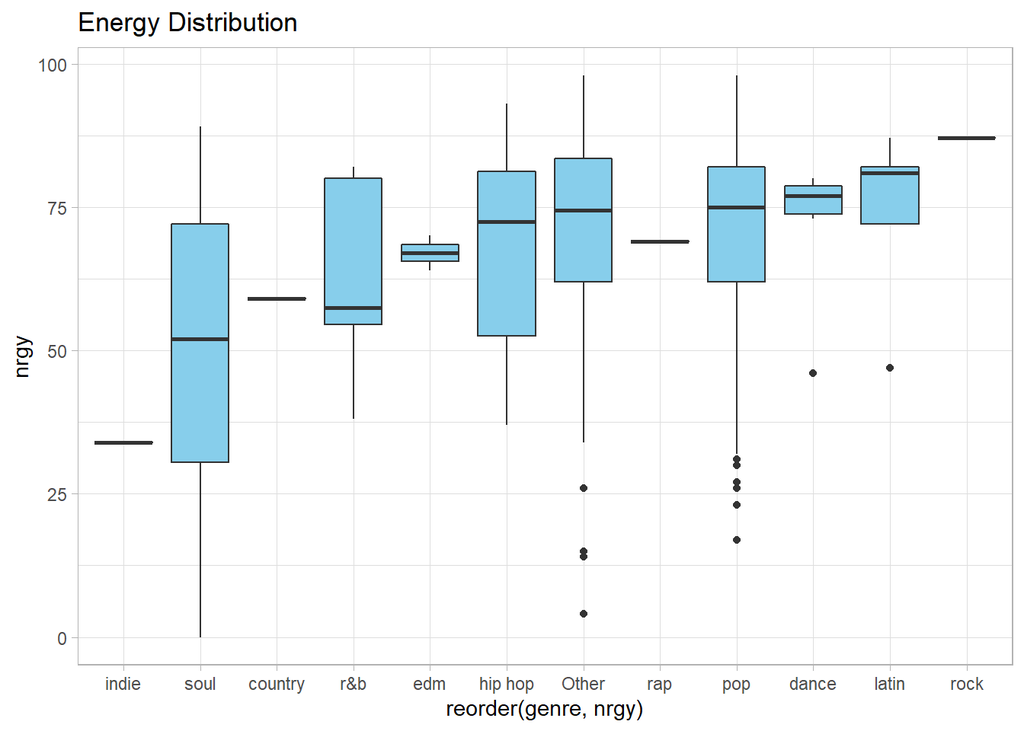

```r
energy <- Spotify%>%ggplot(aes(x=reorder(genre,nrgy),nrgy))+geom_boxplot(fill="skyblue")+ggtitle("Energy Distribution")+theme_light()
energy
```

```r
most_nrgy_artist <-Spotify%>%arrange(desc(nrgy))%>%select(artist,nrgy,title)
most_nrgy_artist
```

```
## # A tibble: 597 x 3
##    artist               nrgy title
##    <chr>               <dbl> <chr>
##  1 Martin Solveig         98 Hello
##  2 Jonas Brothers         98 Pom Poms
##  3 Pitbull                96 Don't Stop the Party (feat. TJR)
##  4 Avril Lavigne          96 Rock N Roll
##  5 OneRepublic            95 All The Right Moves
##  6 Tinie Tempah           95 Written in the Stars (feat. Eric Turner)
##  7 Tinie Tempah           95 Written in the Stars (feat. Eric Turner)
##  8 Little Mix             95 How Ya Doin'? (feat. Missy Elliott)
##  9 5 Seconds of Summer    95 She Looks So Perfect
## 10 Jennifer Lopez         95 Booty
## # ... with 587 more rows
```

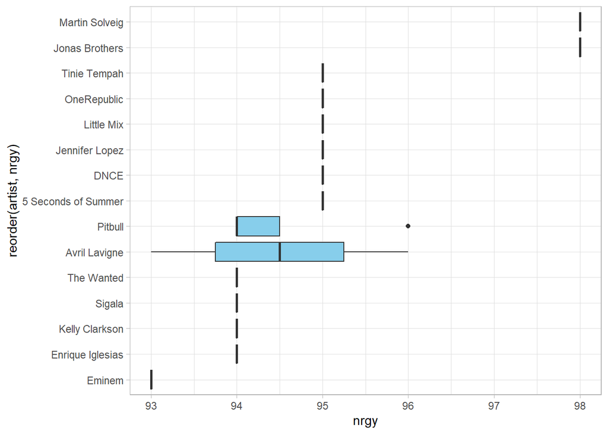

```r
energy_artist <-most_nrgy_artist%>%head(20)%>%ggplot(aes(x=reorder(artist,nrgy),y=nrgy))+geom_boxplot(fill="skyblue")+coord_flip()+theme_light()
energy_artist
```

##4. Analyze the danceability Edm & Latin are the genre with highest median danceability score. Again, no big suprises. Their median score is close to 75 The top songs with highest danceability score are : Bad Liar by Selena Gomez & Drip by Cardi B

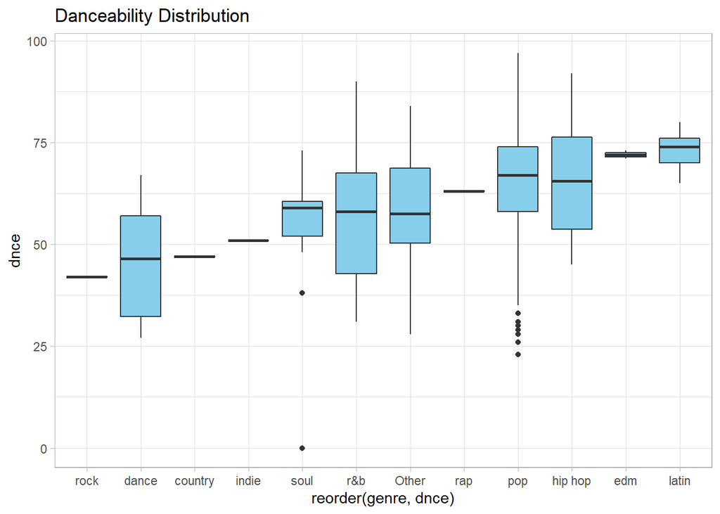

```r
dance <- Spotify%>%ggplot(aes(x=reorder(genre,dnce),dnce))+geom_boxplot(fill="skyblue")+ggtitle("Danceability Distribution")+theme_light()
dance
```

```r
most_dnce_artist <-Spotify%>%arrange(desc(dnce))%>%select(artist,dnce,title)
most_dnce_artist
```

```
## # A tibble: 597 x 3
##    artist             dnce title
##    <chr>             <dbl> <chr>
##  1 Selena Gomez         97 Bad Liar
##  2 Cardi B              97 Drip (feat. Migos)
##  3 Nicki Minaj          96 Anaconda
##  4 Pharrell Williams    93 Come Get It Bae
##  5 Meghan Trainor       93 Me Too
##  6 Missy Elliott        93 WTF (Where They From)
##  7 Cardi B              93 Bodak Yellow
##  8 N.E.R.D              92 Lemon
##  9 Iggy Azalea          91 Fancy
## 10 Jennifer Hudson      90 Dangerous
## # ... with 587 more rows
```

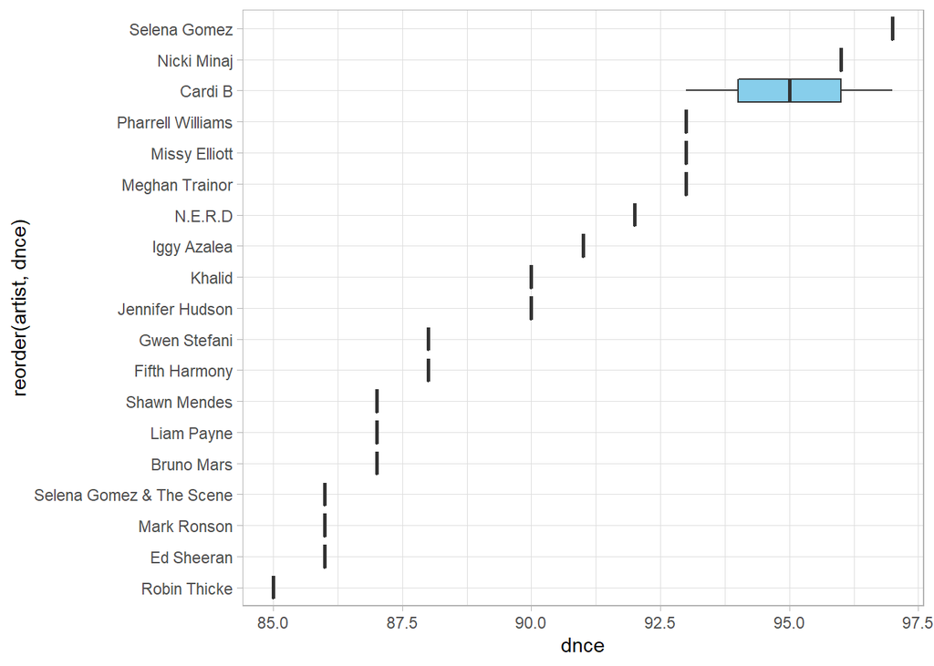

```r
dance_artist <-most_dnce_artist%>%head(20)%>%ggplot(aes(x=reorder(artist,dnce),y=dnce))+geom_boxplot(fill="skyblue")+coord_flip()+theme_light()
dance_artist
```

##5. Analyze the value Latin has the highest median for value, but the top songs with highest value score are : Mmm Yeah by Austin Mahone and Theres nothing holding me back by Shawn Mendes

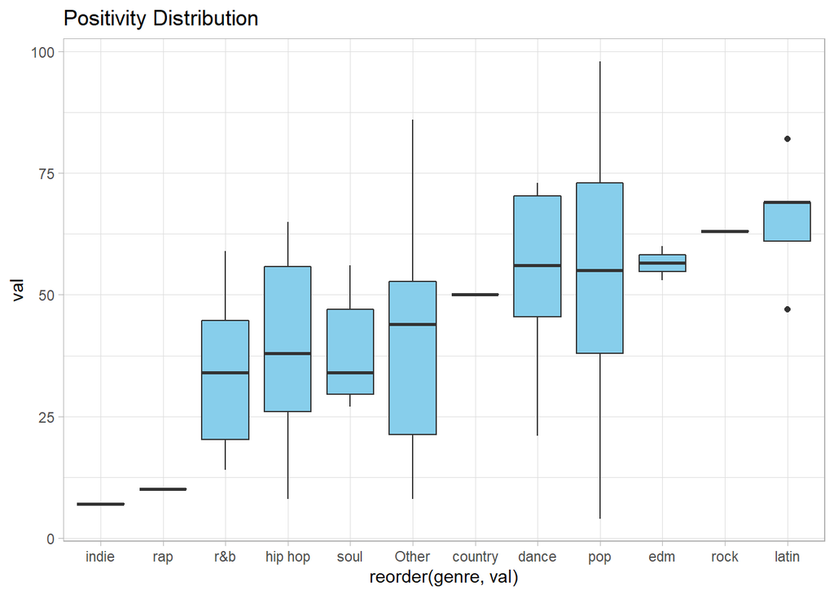

```r
val <- Spotify%>%filter(!dB==-60)%>%ggplot(aes(x=reorder(genre,val),y=val))+geom_boxplot(fill="skyblue")+ggtitle("Positivity Distribution")+theme_light()
val
```

```r
most_val_artist <-Spotify%>%arrange(desc(val))%>%select(artist,val,title)
most_val_artist
```

```
## # A tibble: 597 x 3
##    artist              val title
##    <chr>             <dbl> <chr>
##  1 Austin Mahone        98 "Mmm Yeah (feat. Pitbull)"
##  2 Shawn Mendes         97 "There's Nothing Holdin' Me Back"
##  3 Pharrell Williams    96 "Happy - From \"Despicable Me 2\""
##  4 Meghan Trainor       96 "All About That Bass"
##  5 Pitbull              95 "Don't Stop the Party (feat. TJR)"
##  6 Meghan Trainor       95 "Lips Are Movin"
##  7 Jonas Brothers       95 "Sucker"
##  8 Taylor Swift         94 "Shake It Off"
##  9 Bruno Mars           94 "Treasure"
## 10 Ed Sheeran           94 "Sing"
## # ... with 587 more rows
```

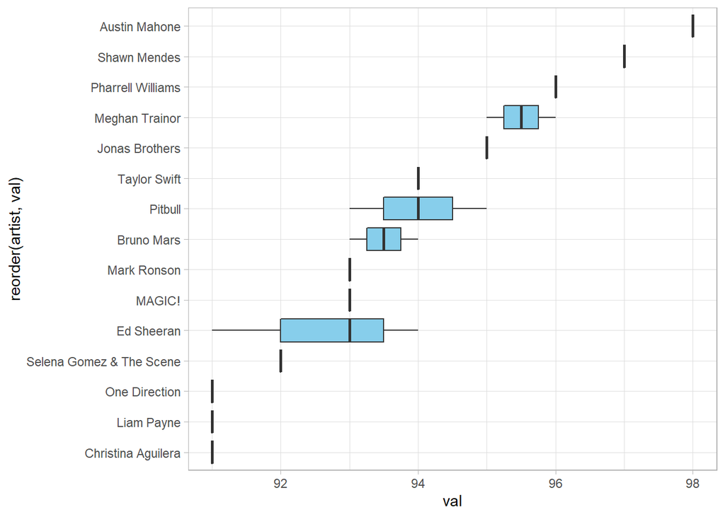

```r
artist <-most_val_artist%>%head(20)%>%ggplot(aes(x=reorder(artist,val),y=val))+geom_boxplot(fill="skyblue")+coord_flip()+theme_light()
artist
```

##6. Analyze the speech Before running the code, I take a guess it should be rap genre with the highest median value And running the code confirms this hunch, and I noticed there are a lot of outlier for pop genre thus I will pull out the songs

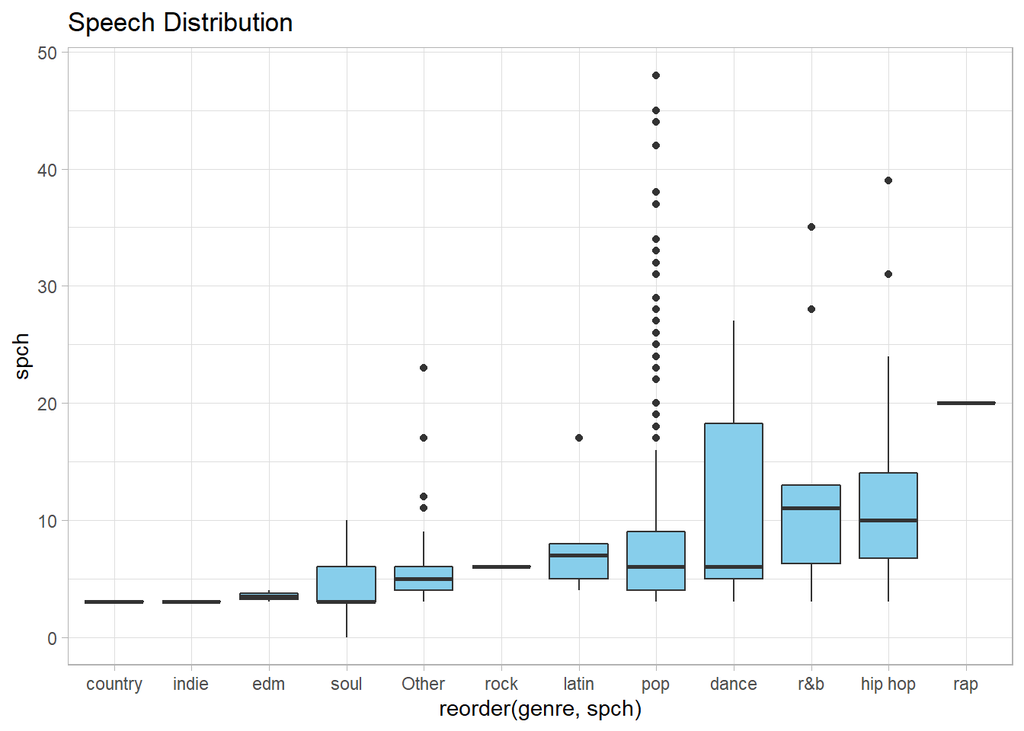

```r
spch <- Spotify%>%ggplot(aes(x=reorder(genre,spch),y=spch))+geom_boxplot(fill="skyblue")+ggtitle("Speech Distribution")+theme_light()
spch
```

```r
spch_pop <-Spotify%>%filter(spch>=20)%>%group_by(artist)%>%summarise(title,spch)
spch_pop
```

```
## # A tibble: 49 x 3
## # Groups:   artist [36]
##    artist           title                                                   spch
##    <chr>            <chr>                                                  <dbl>
##  1 "Alessia Cara"   "How Far I'll Go - From \"Moana\""                        35
##  2 "Alicia Keys"    "Girl On Fire (feat. Nicki Minaj) - Inferno Version"      31
##  3 "Ariana Grande"  "Focus"                                                   24
##  4 "Ariana Grande"  "Side To Side"                                            23
##  5 "Beyonc\xe9"     "Partition"                                               29
##  6 "Beyonc\xe9"     "XO"                                                      26
##  7 "Camila Cabello" "Crying in the Club"                                      38
##  8 "Cardi B"        "Drip (feat. Migos)"                                      26
##  9 "Charlie Puth"   "We Don't Talk Anymore - DROELOE Remix"                   22
## 10 "Christina Agui~ "Something's Got A Hold On Me - Burlesque Original Mo~    27
## # ... with 39 more rows
```

#Now I would like to test some hypthoesis and see if the variables are indeed correlated

##1 Energy & danceability by genre, the higher the energy the song must be more dancable From the graph and the correlation calculation, I can see that the correlation is a bit weak (0.16) I guess this make sense as some songs such as rock genre has lot of energy but it is not danceable

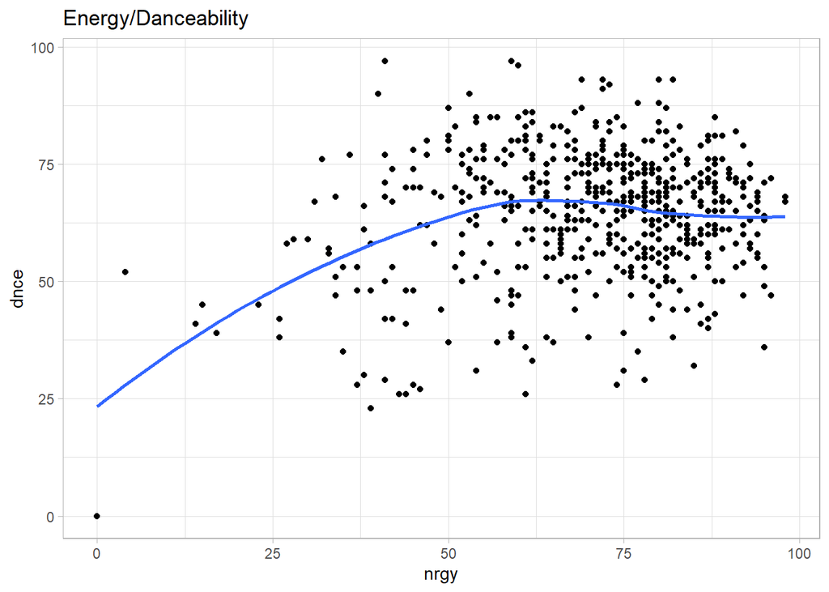

```r
nrgy_dnce <-Spotify%>%ggplot(aes(x=nrgy,y=dnce))+geom_point()+ggtitle("Energy/Danceability")+theme_light()+geom_smooth(se=FALSE)
nrgy_dnce
```

```r
#let's check the correlation
cor(Spotify$nrgy,Spotify$dnce)
```

```
## [1] 0.167183
```

##2 Positivity & Energy.. the more positive song, will convey more energy I am quite please to see that the correlation is 0.41 for this hypthoesis and particularly from genre such as dance/hip hop and pop we can see this Though for hip hop the line is not that well fit

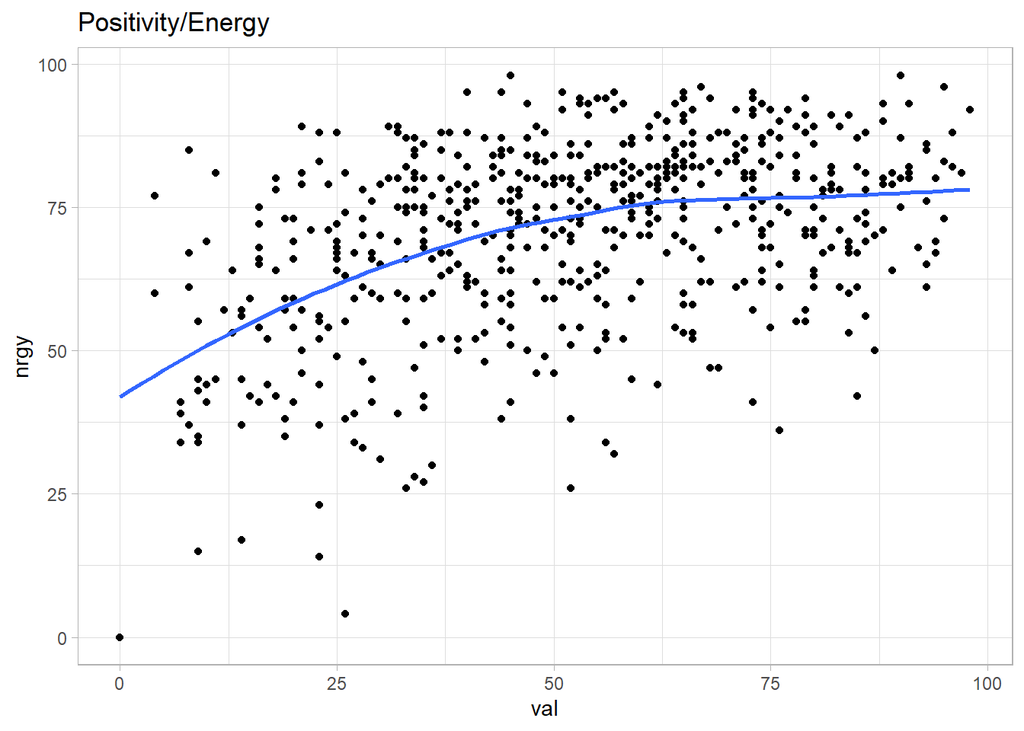

```r
val_nrgy <-Spotify%>%ggplot(aes(x=val,y=nrgy))+geom_point()+ggtitle("Positivity/Energy")+theme_light()+geom_smooth(se=FALSE)
val_nrgy
```

```r
#let's check the correlation
cor(Spotify$val,Spotify$nrgy)
```

```
## [1] 0.4122392
```

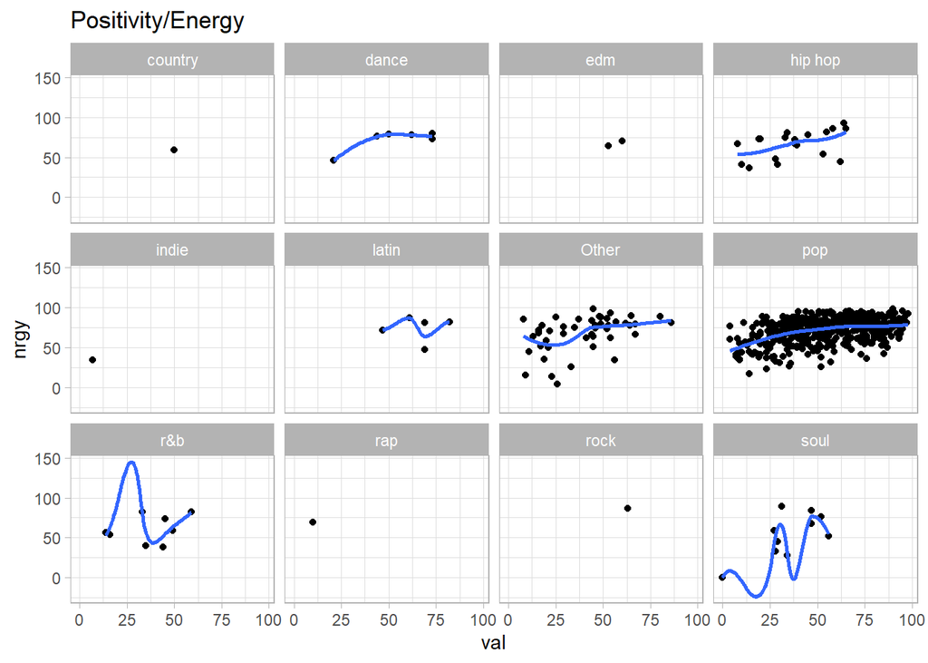

```r
#the correlation result is 0.41. let's check if there are any genre in particular
val_nrgy <-Spotify%>%ggplot(aes(x=val,y=nrgy))+geom_point()+ggtitle("Positivity/Energy")+theme_light()+geom_smooth(se=FALSE)+facet_wrap(~genre)
val_nrgy
```

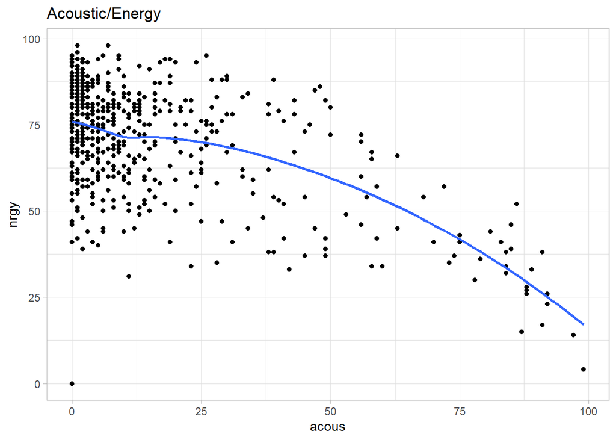

```r
acous_nrgy <-Spotify%>%ggplot(aes(x=acous,y=nrgy))+geom_point()+ggtitle("Acoustic/Energy")+theme_light()+geom_smooth(se=FALSE)
acous_nrgy
```

```r
#let's check the correlation
cor(Spotify$acous,Spotify$nrgy)
```

```
## [1] -0.5637154
```

##4 Last, I would like to check bpm & danceability Before running the code and seeing result from point 1, I would already expect that there should not be any strong correlation between the two And from the correlation we notice that the result is -0.13, but somehow from the plot it is hard to conclude anything

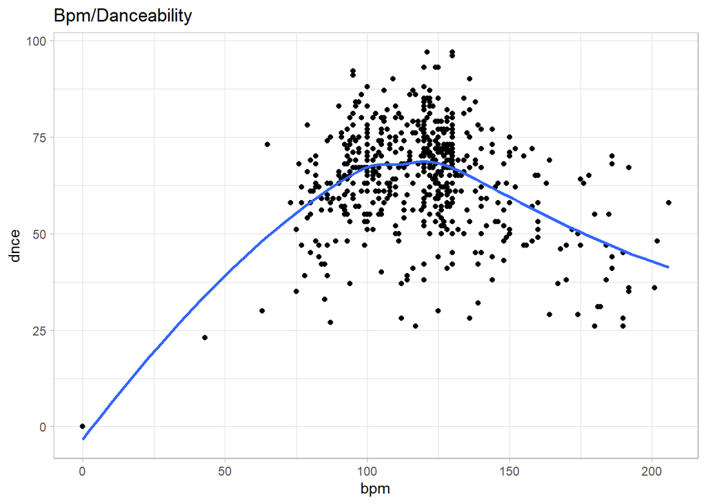

```r
bpm_dnce <-Spotify%>%ggplot(aes(x=bpm,y=dnce))+geom_point()+ggtitle("Bpm/Danceability")+theme_light()+geom_smooth(se=FALSE)
bpm_dnce
```

```r
#let's check the correlation
cor(Spotify$bpm,Spotify$dnce)
```

```
## [1] -0.1320083
```